# Full case study 2: homology-aware beta diversity with repdist

Yixuan Yang

4 September 2026

#### Package

repdist 0.99.0

# 1 Why a representation distance

Bray-Curtis, Jaccard and their relatives compare samples through protein *identity*: two proteins are either the same accession or maximally different. Metaproteomes break that assumption. Two communities can carry the same enzymatic function on accessions that never overlap, and an identity-based distance cannot tell that case apart from any other difference.

`repdist` replaces identity with distance in a protein language model’s representation space. Each sample becomes an abundance-weighted distribution over protein embeddings, and two samples are compared by maximum mean discrepancy (MMD) under an RBF kernel.

This report follows the package vignette’s workflow on a marine plastic-substrate metaproteome:

1. **Beta diversity** with MMD and PERMANOVA.
2. **Structural bins** at a predicted TM-score of 0.7.
3. **Differential abundance** on the bins with DESeq2.
4. **Functional reading** of the most responsive annotated bins.

```r
library(repdist)
library(ggplot2)
library(phyloseq)
```

# 2 The full dataset

The study contains three independent incubations for each of eight substrates: four plastics, two PHBH formulations, filter paper and ambient sediment. PLA is removed before rarefaction because its three runs have exceptionally low and inconsistent depth (92, 766 and 1,832 counts). The other 21 samples are retained and rarefied to the shallowest remaining sample.

```r
path <- here::here("data", "case_study2")
MAX_AA <- 3000L

ps <- readRDS(file.path(path, "ps.rds"))
ps <- prune_samples(data.frame(sample_data(ps))$substrate != "PLA", ps)
ps <- prune_taxa(taxa_sums(ps) > 0, ps)
sample_data(ps)$substrate <- droplevels(sample_data(ps)$substrate)
floor_depth <- min(sample_sums(ps))

set.seed(1)
psd <- rarefy_even_depth(ps, sample.size = floor_depth, rngseed = 1,
                         replace = FALSE, verbose = FALSE)
psd <- prune_taxa(taxa_sums(psd) > 0, psd)

n_after_rarefaction <- ntaxa(psd)
protein_length <- Biostrings::width(refseq(psd)[taxa_names(psd)])
too_long <- protein_length > MAX_AA
long_abundance <- sum(taxa_sums(psd)[too_long]) / sum(taxa_sums(psd))
psd <- prune_taxa(!too_long, psd)

keep <- taxa_names(psd)
psu <- prune_taxa(taxa_names(ps) %in% keep, ps)

counts <- Matrix::Matrix(t(as(otu_table(psd), "matrix")), sparse = TRUE)
counts_raw <- t(as(otu_table(psu), "matrix"))[rownames(counts), keep, drop = FALSE]

md <- data.frame(sample_data(psd))[rownames(counts), ]
md$substrate <- relevel(factor(md$substrate), "Sediment")

tx <- as.data.frame(as(tax_table(psd), "matrix"))[keep, ]
annotation_cols <- c("MantisName", "MicrobeName", "PlasticDB",
                     "Depolymerase", "Description")
annotation <- apply(tx[, annotation_cols, drop = FALSE], 1, function(x) {
  x <- unique(x[!is.na(x) & nzchar(trimws(x)) & !x %in% c("-", "NA")])
  if (length(x)) x[1] else NA_character_
})

taxa <- data.frame(
  protein = keep,
  genome = tx$GenomeID,
  annotation = annotation,
  plastic_db = tx$PlasticDB,
  depolymerase = tx$Depolymerase,
  length = Biostrings::width(refseq(psd)[keep]),
  row.names = keep, stringsAsFactors = FALSE)

d <- list(counts = counts, counts_raw = counts_raw, metadata = md, taxa = taxa,
          sequences = setNames(as.character(refseq(psd)[keep]), keep))

c(samples = nrow(counts), proteins = ncol(counts),
  rarefaction_depth = floor_depth,
  removed_over_3000aa = sum(too_long),
  removed_abundance_pct = round(100 * long_abundance, 3))
```

```
#>               samples              proteins     rarefaction_depth
#>                 21.00               5250.00                655.00
#>   removed_over_3000aa removed_abundance_pct
#>                 12.00                  0.24
```

```r
table(md$substrate)
```

```
#>
#>     Sediment Filter paper         PHBV         PHBH   PHBH Green      PLA/PCL
#>            3            3            3            3            3            3
#>         HDPE
#>            3
```

Rarefaction provides the abundance filter: proteins absent after subsampling are removed. It retained 5262 proteins; the 3,000aa ceiling then removed 12 more, representing only 0.240% of rarefied abundance. The beta-diversity matrix is sparse; `counts_raw` contains unrarefied counts for exactly the same proteins and samples.

# 3 Embedding

`embed_proteins()` embeds every sequence whole. The full TM-Vec embeddings are cached outside the render because model inference is not part of the statistical analysis.

```r
cached <- readRDS(file.path(path, "embeddings_tmvec1_large.rds"))$Z
stopifnot(all(keep %in% rownames(cached)))
Z <- cached[keep, , drop = FALSE]
dim(Z)
```

```
#> [1] 5250  512
```

TM-Vec’s head was trained to regress TM-score, so cosine similarity between two embeddings is a predicted TM-score. `known_models()` lists the other registered representations.

```r
names(known_models())
```

```
#> [1] "tmvec"     "tmvec-300" "esm2-8m"   "esm2-150m" "esm2-650m"
```

# 4 The protein ground distance

`repdist_matrix()` builds the condensed protein-by-protein cosine distance used by binning and QC. This is the expensive object in the full analysis.

```r
G_cos <- repdist_matrix(Z)
```

`bin_proteins()` reads this scale as predicted TM-score. `sample_repdist()` instead builds a Euclidean RBF internally so the kernel remains positive semi-definite. On unit-norm TM-Vec embeddings the two ground distances are monotone transforms of one another.

```r
c(median_predicted_TM = round(1 - median(G_cos), 3),
  pairs_above_0.7 = sum(G_cos <= 0.3))
```

```
#> median_predicted_TM     pairs_above_0.7
#>               0.347          156850.000
```

# 5 Step 1: beta diversity

Bray-Curtis is the protein-identity baseline. MMD asks how far apart different proteins actually are. The sparse count matrix stays sparse throughout the MMD calculation.

```r
D <- list(
  `Bray-Curtis` = vegan::vegdist(as.matrix(d$counts), "bray"),
  `MMD` = sample_repdist(d$counts, Z))
```

Both are abundance-weighted, so richness is checked before interpreting the substrate effect.

```r
rich <- vegan::specnumber(as.matrix(d$counts))
round(vapply(D, function(x) cor(rich, rowMeans(as.matrix(x))), numeric(1)), 2)
```

```
#> Bray-Curtis         MMD
#>        0.68       -0.42
```

## 5.1 PERMANOVA

The incubations are independent replicates, so permutations are not blocked.

```r
res <- do.call(rbind, lapply(names(D), function(n) {
  set.seed(1)
  a <- vegan::adonis2(D[[n]] ~ substrate, data = md,
                      by = "terms", permutations = 999)
  data.frame(distance = n, R2 = round(a["substrate", "R2"], 3),
             F = round(a["substrate", "F"], 2), p = a["substrate", "Pr(>F)"])
}))
knitr::kable(res, row.names = FALSE)
```

| distance | R2 | F | p |
| --- | --- | --- | --- |
| Bray-Curtis | 0.436 | 1.81 | 0.001 |
| MMD | 0.612 | 3.68 | 0.001 |

## 5.2 Ordination

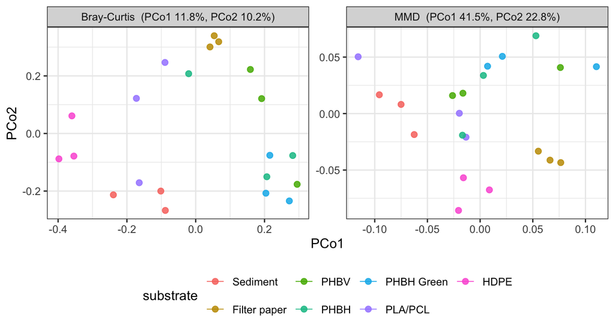

```r
ord <- do.call(rbind, lapply(names(D), function(n) {
  e <- cmdscale(D[[n]], k = 2, eig = TRUE)
  rel <- 100 * e$eig / sum(e$eig[e$eig > 0])
  data.frame(
    Axis1 = e$points[, 1], Axis2 = e$points[, 2],
    substrate = md[rownames(e$points), "substrate"],
    panel = sprintf("%s  (PCo1 %.1f%%, PCo2 %.1f%%)", n, rel[1], rel[2]))
}))

ggplot(ord, aes(Axis1, Axis2, colour = substrate)) +
  geom_point(size = 2, alpha = 0.85) +
  stat_ellipse(type = "t", linewidth = 0.3) +
  facet_wrap(~ panel, scales = "free") +
  labs(x = "PCo1", y = "PCo2", colour = "substrate") +
  theme_bw() +
  theme(legend.position = "bottom")
```

# 6 Step 2: structural bins at TM-score 0.7

`bin_proteins()` uses complete linkage, so every pair inside a bin meets the threshold. A 0.7 cut is stricter than the conventional same-fold boundary of 0.5: bins are tighter, at the cost of more singletons.

```r
b <- bin_proteins(G_cos, min_sim = 0.7)
```

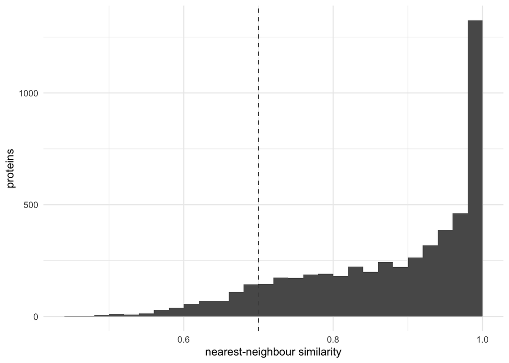

```r
plot_similarity_profile(G_cos, min_sim = 0.7)
```

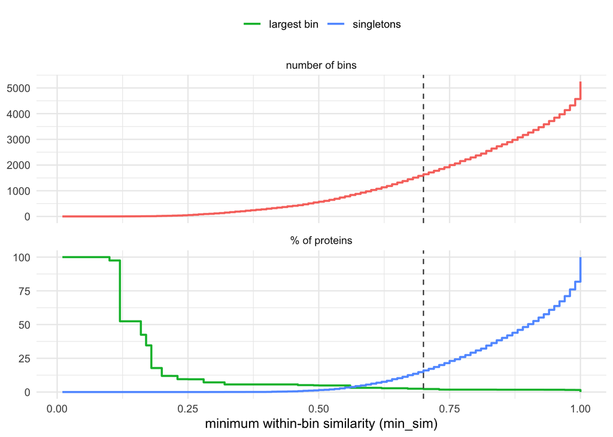

```r
plot_bin_profile(b, min_sim = 0.7)
```

The unrarefied counts roll up to bin level with one `rowsum()`.

```r
bin <- setNames(rep(names(b$clusters), lengths(b$clusters)), unlist(b$clusters))
bin_counts <- t(rowsum(t(d$counts_raw), bin[colnames(d$counts_raw)]))
c(proteins = ncol(d$counts_raw), bins = ncol(bin_counts))
```

```
#> proteins     bins
#>     5250     1643
```

```r
sizes <- lengths(b$clusters)
table(cut(sizes, c(0, 1, 2, 5, 10, Inf),
          labels = c("1", "2", "3-5", "6-10", ">10")))
```

```
#>
#>    1    2  3-5 6-10  >10
#>  840  326  294  111   72
```

840 proteins remain singleton bins. The other 803 bins combine structurally related accessions, reducing the number of tested units by a factor of 3.2.

# 7 Step 3: differential abundance with DESeq2

DESeq2 fits a negative-binomial model per bin on unrarefied counts. Substrate is tested by likelihood ratio against an intercept-only model.

```r
dds <- DESeq2::DESeqDataSetFromMatrix(t(bin_counts), md,
                                      design = ~ substrate)
dds <- DESeq2::DESeq(dds, test = "LRT", reduced = ~ 1,
                     sfType = "poscounts", quiet = TRUE)
res_lrt <- DESeq2::results(dds)

c(bins_tested = nrow(res_lrt),
  substrate_significant = sum(res_lrt$padj <= 0.05, na.rm = TRUE))
```

```
#>           bins_tested substrate_significant
#>                  1643                    59
```

Each significant bin is assigned its largest shrunken substrate-vs-sediment fold change for ranking and display.

```r
lev <- setdiff(levels(md$substrate), "Sediment")
coef_names <- setNames(paste0("substrate_", make.names(lev), "_vs_Sediment"), lev)
ddsw <- DESeq2::nbinomWaldTest(dds, quiet = TRUE)
stopifnot(all(coef_names %in% DESeq2::resultsNames(ddsw)))
shrunk <- lapply(coef_names, function(coef)
  DESeq2::lfcShrink(ddsw, coef = coef, type = "normal", quiet = TRUE))
names(shrunk) <- lev
fc <- vapply(shrunk, function(o) o$log2FoldChange, numeric(nrow(res_lrt)))
rownames(fc) <- rownames(res_lrt)

sig <- rownames(res_lrt)[!is.na(res_lrt$padj) & res_lrt$padj <= 0.05]
best <- apply(abs(fc[sig, , drop = FALSE]), 1, which.max)
top <- data.frame(
  bin = sig,
  members = sizes[sig],
  padj = formatC(res_lrt[sig, "padj"], digits = 2, format = "e"),
  substrate = lev[best],
  log2FC = round(fc[cbind(sig, lev[best])], 2))
top <- top[order(-abs(top$log2FC)), ]
knitr::kable(head(top, 8), row.names = FALSE)
```

| bin | members | padj | substrate | log2FC |
| --- | --- | --- | --- | --- |
| bin31 | 22 | 1.30e-04 | Filter paper | -6.71 |
| bin106 | 8 | 1.75e-09 | PLA/PCL | 5.46 |
| bin82 | 10 | 3.86e-03 | Filter paper | 5.39 |
| bin27 | 24 | 5.34e-04 | PHBH Green | 5.29 |
| bin172 | 6 | 3.59e-12 | HDPE | 5.23 |
| bin29 | 23 | 2.52e-03 | PHBH Green | 5.01 |
| bin114 | 8 | 3.10e-02 | Filter paper | -4.99 |
| bin125 | 7 | 3.13e-07 | PLA/PCL | 4.90 |

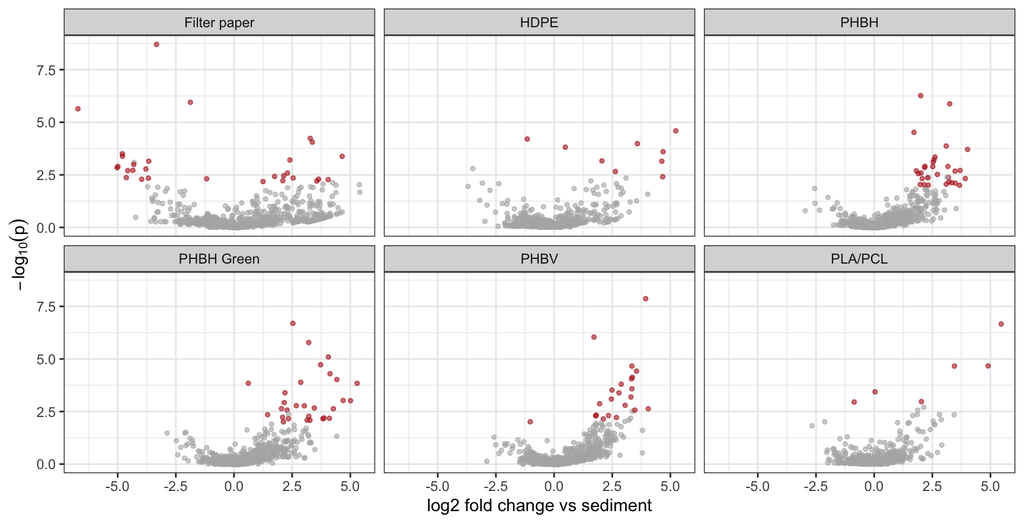

```r
volc <- do.call(rbind, lapply(lev, function(l) {
  o <- shrunk[[l]]
  data.frame(bin = rownames(o), substrate = l,
             log2FoldChange = o$log2FoldChange, pvalue = o$pvalue,
             reject = !is.na(o$padj) & o$padj <= 0.05)
}))

ggplot(volc, aes(log2FoldChange, -log10(pvalue), color = reject)) +
  geom_point(alpha = 0.6, size = 1) +
  facet_wrap(~ substrate, nrow = 2) +
  scale_color_manual(values = c(`FALSE` = "grey70", `TRUE` = "firebrick"),
                     guide = "none") +
  labs(x = "log2 fold change vs sediment", y = expression(-log[10](p))) +
  theme_bw()
```

# 8 Step 4: responsive bins, read functionally

Select the three most responsive multi-member bins with at least two annotated proteins.

```r
n_ann <- vapply(b$clusters[top$bin],
                function(m) sum(!is.na(d$taxa[m, "annotation"])), integer(1))
picks <- head(top[top$members > 1 & n_ann >= 2, ], 3)
knitr::kable(picks, row.names = FALSE)
```

| bin | members | padj | substrate | log2FC |
| --- | --- | --- | --- | --- |
| bin31 | 22 | 1.30e-04 | Filter paper | -6.71 |
| bin106 | 8 | 1.75e-09 | PLA/PCL | 5.46 |
| bin82 | 10 | 3.86e-03 | Filter paper | 5.39 |

```r
info <- do.call(rbind, lapply(seq_len(nrow(picks)), function(i) {
  m <- b$clusters[[picks$bin[i]]]
  data.frame(
    bin = picks$bin[i],
    genome = d$taxa[m, "genome"],
    annotation = substr(d$taxa[m, "annotation"], 1, 52),
    PlasticDB = d$taxa[m, "plastic_db"],
    depolymerase = d$taxa[m, "depolymerase"],
    mean_Sediment = round(colMeans(d$counts_raw[md$substrate == "Sediment", m,
                                                  drop = FALSE]), 1),
    mean_top = round(colMeans(d$counts_raw[md$substrate == picks$substrate[i], m,
                                             drop = FALSE]), 1))
}))
knitr::kable(info, row.names = FALSE)
```

| bin | genome | annotation | PlasticDB | depolymerase | mean_Sediment | mean_top |
| --- | --- | --- | --- | --- | --- | --- |
| bin31 | 1-2DA1.bin.lowDepth.fa | outer membrane protein OmpU | - | NA | 0.0 | 0.0 |
| bin31 | 1-2DA1.bin.38.fa | outer membrane protein OmpU | - | NA | 0.3 | 0.0 |
| bin31 | 14-2DG2.bin.61.fa | Alginate export | - | NA | 0.0 | 0.0 |
| bin31 | 14-2DG2.bin.114.fa | Alginate export | - | NA | 7.7 | 0.0 |
| bin31 | 17-2DI2.bin.43.fa | Alginate export | - | NA | 0.0 | 0.0 |
| bin31 | 1-2DA1.bin.29.fa | NA | - | NA | 2.0 | 0.0 |
| bin31 | 13-2DG1.bin.67.fa | NA | - | NA | 11.7 | 0.0 |
| bin31 | 13-2DG1.bin.92.fa | NA | - | NA | 0.7 | 0.0 |
| bin31 | 13-2DG1.bin.21.fa | NA | - | NA | 3.7 | 0.0 |
| bin31 | 13-2DG1.bin.23.fa | NA | - | NA | 0.3 | 0.0 |
| bin31 | 13-2DG1.bin.60.fa | NA | - | NA | 0.0 | 0.0 |
| bin31 | 13-2DG1.bin.unbinned.fa | NA | - | NA | 0.0 | 0.0 |
| bin31 | 13-2DG1.bin.48.fa | NA | - | NA | 3.0 | 0.0 |
| bin31 | 14-2DG2.bin.unbinned.fa | NA | - | NA | 0.0 | 0.0 |
| bin31 | 16-2DI1.bin.19.fa | NA | - | NA | 0.0 | 0.0 |
| bin31 | 16-2DI1.bin.72.fa | NA | - | NA | 1.0 | 0.0 |
| bin31 | 16-2DI1.bin.unbinned.fa | NA | - | NA | 0.0 | 0.0 |
| bin31 | 17-2DI2.bin.64.fa | NA | - | NA | 0.0 | 0.0 |
| bin31 | 18-2DI3.bin.1.fa | NA | - | NA | 2.7 | 0.0 |
| bin31 | 18-2DI3.bin.50.fa | NA | - | NA | 0.0 | 0.0 |
| bin31 | 2-2DA2.bin.unbinned.fa | NA | - | NA | 0.0 | 0.0 |
| bin31 | 24-1FND7.bin.98.fa | NA | - | NA | 0.0 | 0.0 |
| bin106 | 1-2DA1.bin.62.fa | iron complex outermembrane recepter protein | - | NA | 0.0 | 0.3 |
| bin106 | 10-2DD1.bin.96.fa | iron complex outermembrane recepter protein | - | NA | 0.0 | 29.3 |
| bin106 | 10-2DD1.bin.96.fa | iron complex outermembrane recepter protein | - | NA | 0.0 | 0.3 |
| bin106 | 10-2DD1.bin.96.fa | iron complex outermembrane recepter protein | - | NA | 0.0 | 120.7 |
| bin106 | 10-2DD1.bin.96.fa | iron complex outermembrane recepter protein | - | NA | 0.0 | 6.0 |
| bin106 | 11-2DD2.bin.60.fa | iron complex outermembrane recepter protein | - | NA | 0.0 | 3.3 |
| bin106 | 11-2DD2.bin.85.fa | iron complex outermembrane recepter protein | - | NA | 0.0 | 0.0 |
| bin106 | 9-2DC3.bin.75.fa | iron complex outermembrane recepter protein | - | NA | 0.0 | 0.3 |
| bin82 | 12-2DD3.bin.69.fa | TonB-dependent receptor | - | NA | 0.0 | 0.7 |
| bin82 | 12-2DD3.bin.69.fa | TonB-dependent receptor | - | NA | 0.0 | 26.3 |
| bin82 | 17-2DI2.bin.20.fa | TonB-dependent receptor | - | NA | 0.0 | 3.0 |
| bin82 | 17-2DI2.bin.20.fa | TonB-dependent receptor | - | NA | 0.0 | 3.3 |
| bin82 | 22-1FND2.bin.unbinned.fa | TonB-dependent receptor | - | NA | 0.0 | 68.7 |
| bin82 | 22-1FND2.bin.44.fa | TonB-dependent receptor | - | NA | 0.0 | 2.0 |
| bin82 | 22-1FND2.bin.38.fa | TonB-dependent receptor | - | NA | 0.0 | 4.7 |
| bin82 | 22-1FND2.bin.38.fa | TonB-dependent receptor | - | NA | 0.0 | 10.0 |
| bin82 | 23-1FND3.bin.31.fa | TonB-dependent receptor | - | NA | 0.0 | 11.7 |
| bin82 | 24-1FND7.bin.89.fa | TonB-dependent receptor | - | NA | 0.7 | 123.3 |

The complete-linkage guarantee can be inspected directly for the leading annotated bin.

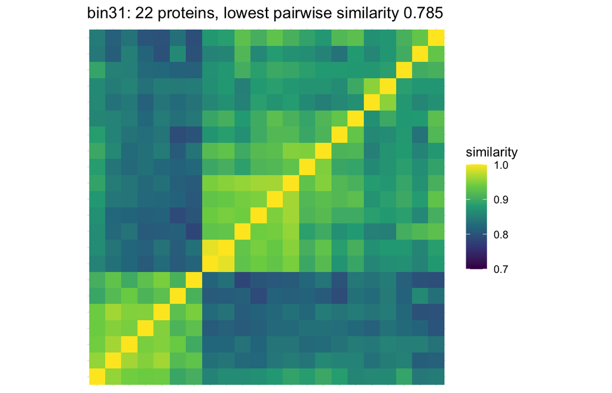

```r
plot_bin_similarity(b, picks$bin[1], G_cos)
```

# 9 Practical notes

**Rarefy first** for whole-community distances. The differential-abundance model uses the corresponding unrarefied counts and handles depth through size factors.

**Memory.** `repdist_matrix()` remains quadratic because binning needs the condensed protein distance. `sample_repdist()` does not: it accumulates two-dimensional 1000-by-1000 kernel tiles directly into the sample Gram matrix, and sparse counts remain sparse.

**Bandwidth.** `sample_repdist()` returns its bandwidth as `attr(, "sigma")`; pass it back when comparisons across studies need one fixed kernel.